# TP2 - CART

##### Arbol ansiedad podado

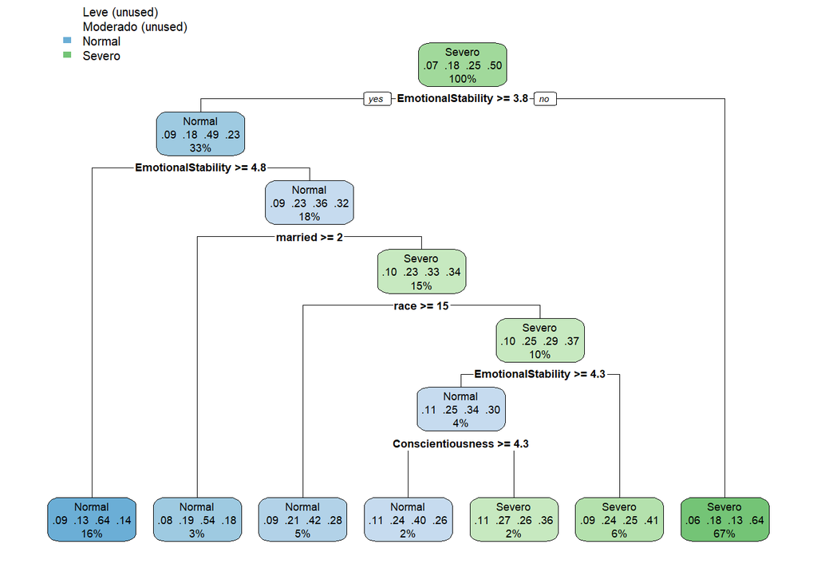

```r
modelo_Cart_ansiedad_pruned <- prune(modelo_cart_ansiedad, cp = 0.002)

rpart.plot(modelo_Cart_ansiedad_pruned)
```

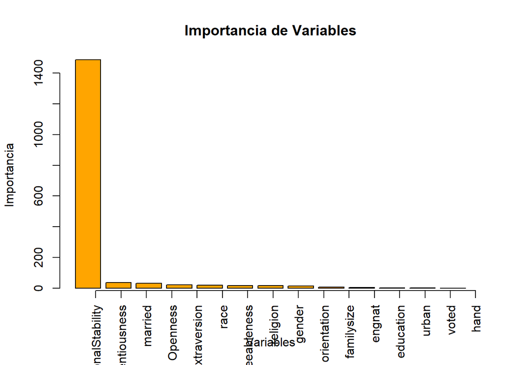

```r
#Importancia
importancia_variables_ansiedad_pruned <- data.frame(variable = names(modelo_Cart_ansiedad_pruned$variable.importance),
                                     importancia = modelo_Cart_ansiedad_pruned$variable.importance)

importancia_variables_ansiedad_pruned <- importancia_variables_ansiedad_pruned[order(-importancia_variables_ansiedad_pruned$importancia), ]

barplot(importancia_variables_ansiedad_pruned$importancia,
        col = "orange", main = "Importancia de Variables",
        xlab = "Variables", ylab = "Importancia")

#Acomodamos nombres
axis(1, at = seq_along(importancia_variables_ansiedad$variable),
     labels = importancia_variables_ansiedad$variable, las = 2, cex.names= 0.4)
```

El árbol resultante al podarlo hacia un cp = 0.002 resulta muy similar al que vimos anteriormente de Depresion.

#### Stress

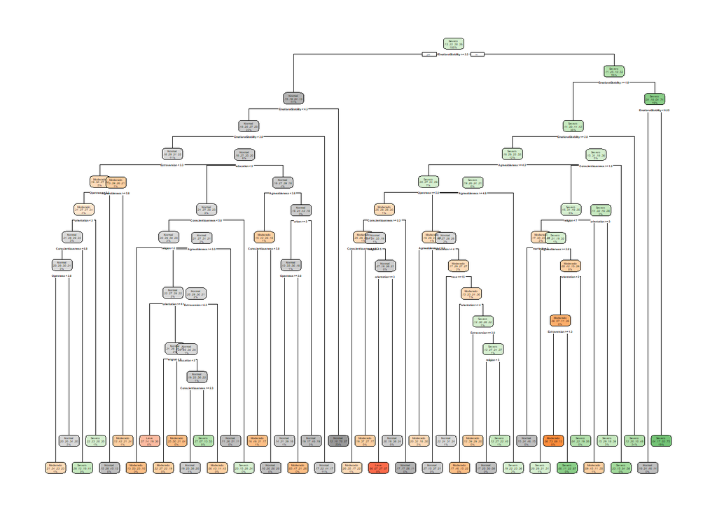

```r
variables_predictoras_stress <- c("Extraversion", "Agreeableness", "Conscientiousness", "EmotionalStability", "Openness", "education", "urban", "gender", "engnat", "hand", "religion", "orientation", "race", "voted", "married", "familysize", "Stress_cat")


df_entrenamiento_stress <- df_entrenamiento[variables_predictoras_stress]

#Fit
modelo_cart_stress <- rpart(formula = Stress_cat ~. , data = df_entrenamiento_stress, method = "class", control = rpart.control(cp = 0.00039))



#Grafico arbol
rpart.plot(modelo_cart_stress)
```

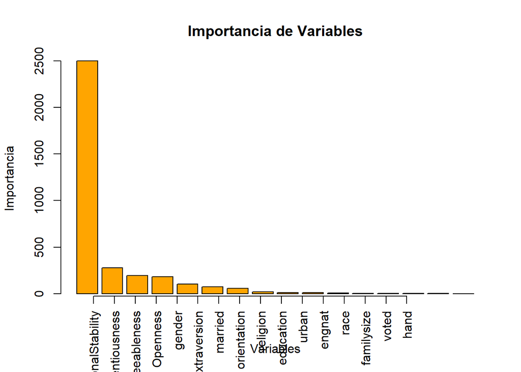

```r
#Importancia
importancia_variables_stress<- data.frame(variable = names(modelo_cart_stress$variable.importance),
                                     importancia = modelo_cart_stress$variable.importance)

importancia_variables_stress <- importancia_variables_stress[order(-importancia_variables_stress$importancia), ]

barplot(importancia_variables_stress$importancia,
        col = "orange", main = "Importancia de Variables",
        xlab = "Variables", ylab = "Importancia")

#Acomodamos nombres
axis(1, at = seq_along(importancia_variables_stress$variable),
     labels = importancia_variables_stress$variable, las = 2, cex.names= 0.4)
```

En principio armamos un árbol saturado para luego podarlo. No se ve que haya diferencias grandes con la importancia de variables de Depresión ni Ansiedad, nuevamente las variables más fuertes parecen ser los rasgos de personalidad.

```r
tabla_variables_stress <- as.data.frame(modelo_cart_stress$frame$var[modelo_cart_stress$frame$var != "<leaf>"])
names(tabla_variables_stress) <- c("variable")
tabla_variables_stress %>%
  group_by(variable) %>%
  summarise(n = n()) %>%
  mutate(freq = round(n / sum(n), 2)) %>%
  arrange(-n)
```

```
## # A tibble: 12 × 3
##    variable               n  freq
##    <chr>              <int> <dbl>
##  1 Agreeableness          7  0.16
##  2 Conscientiousness      7  0.16
##  3 EmotionalStability     6  0.13
##  4 orientation            6  0.13
##  5 Extraversion           4  0.09
##  6 Openness               4  0.09
##  7 religion               4  0.09
##  8 education              3  0.07
##  9 engnat                 1  0.02
## 10 married                1  0.02
## 11 race                   1  0.02
## 12 urban                  1  0.02
```

Aquí es interesante que Amabilidad y Escrupulosidad son utilizadas más veces para hacer divisiones en el árbol.

##### Arbol Stress podado

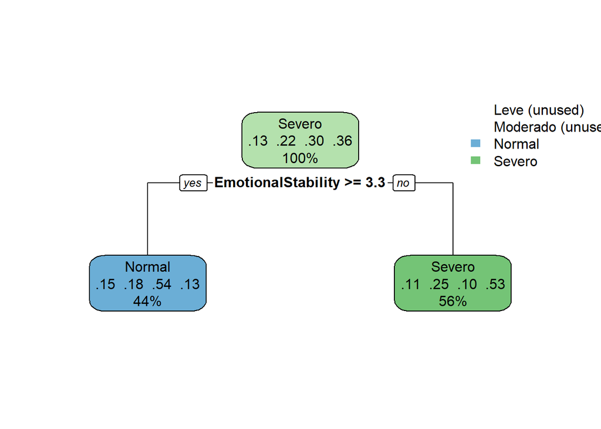

```r
modelo_Cart_stress_pruned <- prune(modelo_cart_stress, cp = 0.002)

rpart.plot(modelo_Cart_stress_pruned)
```

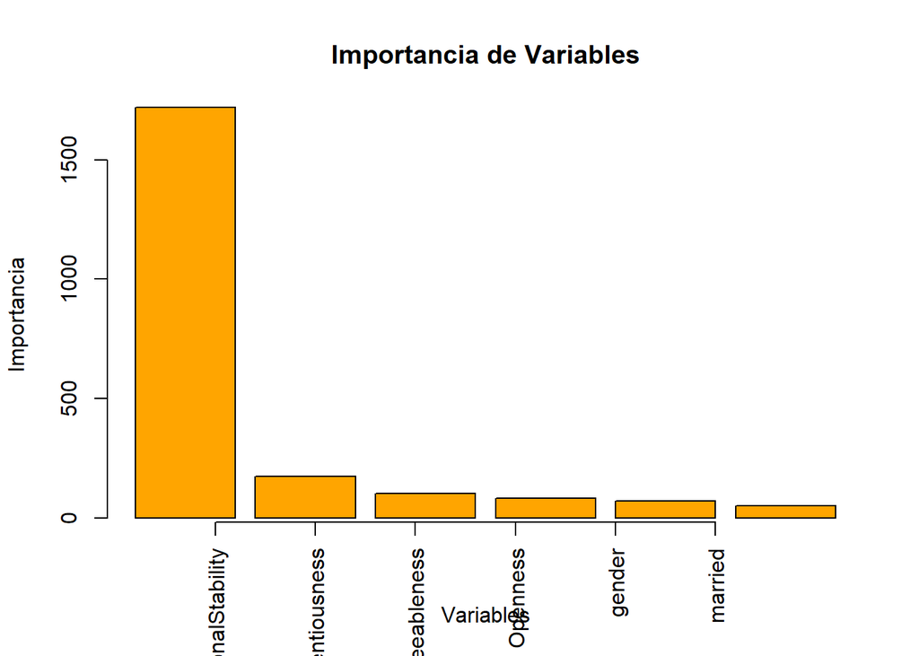

```r
#Importancia
importancia_variables_stress_pruned <- data.frame(variable = names(modelo_Cart_stress_pruned$variable.importance),
                                     importancia = modelo_Cart_stress_pruned$variable.importance)

importancia_variables_stress_pruned <- importancia_variables_stress_pruned[order(-importancia_variables_stress_pruned$importancia), ]

barplot(importancia_variables_stress_pruned$importancia,
        col = "orange", main = "Importancia de Variables",
        xlab = "Variables", ylab = "Importancia")

#Acomodamos nombres
axis(1, at = seq_along(importancia_variables_stress_pruned$variable),
     labels = importancia_variables_stress_pruned$variable, las = 2, cex.names= 0.4)
```

Vemos que al podar el árbol a cp 0.002 directamente tenemos, para Stress, dos nodos terminales y una simple división en base a Estabilidad Emocional, por lo que nuevamente esta variable es un fuerte predictor para el caso binario.